# Information Criteria

Lecture 18

April 7, 2025

# Review of Last Class

## Information and Uncertainty

**Key Idea**: “Information” as reduction in uncertainty from projection.

**Entropy**: $H(p) = \mathbb{E}[\log(p)] = -\sum_{i=1}^n p_i \log p_i$

## Kullback-Leibler Divergence

Measure of “distance” between “true” distribution $p$ and surrogate/projection distribution $q$:

$$D_{KL}(p, q) = \sum_i p_i (\log(p_i) - \log(q_i))$$

**Intuitively**: What is the surprise from using $q$ to predict $p$?

## Entropy and Log-Score

Suppose we have two projections $q$ and $r$ for a “true” data-generating process $p$:

$$D_{KL}(p, q) - D_{KL}(p, r) = \sum_i p_i (\log(r_i) - \log(q_i))$$

## Deviance Scale

This **log-predictive-density** score is better when larger.

Common to see this converted to **deviance**, which is $-2\text{lppd}$:

- $-1$ reorients so smaller is better;
- Multiplied by $2$ for historical reasons (cancels out the -1/2 in the Gaussian likelihood).

## Deviance and Degrees of Freedom

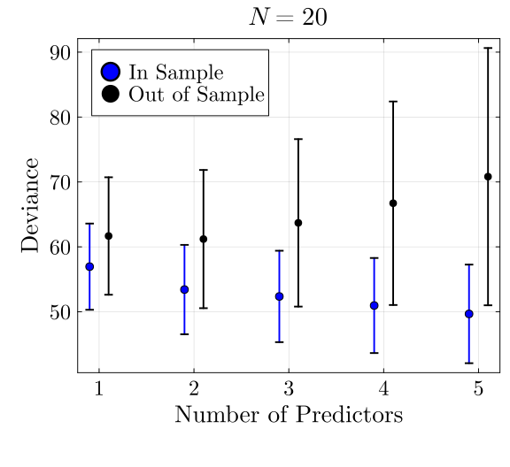

(a) Simulation of in vs. out of sample deviance calculations with increasing number of simulations

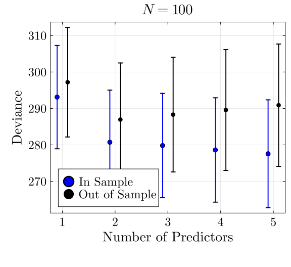

(b)

Figure 1

```julia
function calculate_deviance(y_gen, x_gen, y_oos, x_oos; degree=2, reg=Inf)
    # fit model
    lb = [-5 .+ zeros(degree); 0.01]
    ub = [5 .+ zeros(degree); 10.0]
    p0 = [zeros(degree); 5.0]

    function model_loglik(p, y, x, reg)
        if mean(p[1:end-1]) <= reg
            ll = 0
            for i = 1:length(y)
                μ = sum(x[i, 1:degree] .* p[1:end-1])
                ll += logpdf(Normal(μ, p[end]), y[i])
            end
        else
            ll = -Inf
        end
        return ll
    end

    result = optimize(p -> -model_loglik(p, y_gen, x_gen, reg), lb, ub, p0)
    θ = result.minimizer

    function deviance(p, y_pred, x_pred)
        dev = 0
        for i = 1:length(y_pred)
            μ = sum(x_pred[i, 1:degree] .* p[1:end-1])
            dev += -2 * logpdf(Normal(μ, p[end]), y_pred[i])
        end
        return dev
    end

    dev_is = deviance(θ, y_gen, x_gen)
    dev_oos = deviance(θ, y_oos, x_oos)
    return (dev_is, dev_oos)
end


N_sim = 10_000

function simulate_deviance(N_sim, N_data; reg=Inf)
    d_is = zeros(5, 4)
    for d = 1:5
        dev_out = zeros(N_sim, 2)
        for n = 1:N_sim
            x_gen = rand(Uniform(-2, 2), (N_data, 5))
            μ_gen = [0.1 * x_gen[i, 1] - 0.3 * x_gen[i, 2] for i in 1:N_data]
            y_gen = rand.(Normal.(μ_gen, 1))

            x_oos = rand(Uniform(-2, 2), (N_data, 5))
            μ_oos = [0.1 * x_oos[i, 1] - 0.3 * x_oos[i, 2] for i in 1:N_data]
            y_oos = rand.(Normal.(μ_oos, 1))

            dev_out[n, :] .= calculate_deviance(y_gen, x_gen, y_oos, x_oos, degree=d, reg=reg)
        end
        d_is[d, 1] = mean(dev_out[:, 1])
        d_is[d, 2] = std(dev_out[:, 1])
        d_is[d, 3] = mean(dev_out[:, 2])
        d_is[d, 4] = std(dev_out[:, 2])
    end
    return d_is
end

d_20 = simulate_deviance(N_sim, 20)
p1 = scatter(collect(1:5) .- 0.1, d_20[:, 1], yerr=d_20[:, 2], color=:blue, linecolor=:blue, lw=2, markersize=5, label="In Sample", xlabel="Number of Predictors", ylabel="Deviance", title=L"$N = 20$", grid=true)
scatter!(p1, collect(1:5) .+ 0.1, d_20[:, 3], yerr=d_20[:, 4], lw=2, markersize=5, color=:black, linecolor=:black, label="Out of Sample")
plot!(p1, size=(600, 550))

d_100 = simulate_deviance(N_sim, 100)
p2 = scatter(collect(1:5) .- 0.1, d_100[:, 1], yerr=d_100[:, 2], color=:blue, linecolor=:blue, lw=2, markersize=5, label="In Sample", xlabel="Number of Predictors", ylabel="Deviance", title=L"$N = 100$", grid=true)
scatter!(p2, collect(1:5) .+ 0.1, d_100[:, 3], yerr=d_100[:, 4], lw=2, markersize=5, color=:black, linecolor=:black, label="Out of Sample")
plot!(p2, size=(600, 550))

display(p1)
display(p2)
```

## Cross-Validation and Over-/Under-Fitting

**Cross-Validation and related measures cannot detect overfitting when information leaks from the full dataset to the trained model**.

## Cross-Validation and Over-/Under-Fitting

In other words:

- Do not select features based on the entire dataset, then do C-V on that model.
- Must treat variable/feature selection as part of the C-V process.
- *A priori* model specification (before looking at the data) avoids this problem.

# Out of Sample Predictive Accuracvy

## Expected Out-Of-Sample Predictive Accuracy

We want to compute the *expected out-of-sample log-predictive density*

$$\begin{align}
\text{elpd} &= \text{expected log-predictive density for } \tilde{y}_i \\
&= \mathbb{E}_P \left[\log p(\tilde{y}_i)\right] \\
&= \int \log\left(p(\tilde{y}_i)\right) P(\tilde{y}_i)\,d\tilde{y}.
\end{align}$$

## Expected Out-Of-Sample Predictive Accuracy

What is the challenge?

We don’t know $P$ (the distribution of new data)!

## Expected Out-Of-Sample Predictive Accuracy

We need some measure of the error induced by using an approximating distribution $Q$ from some model.

$$\begin{align}
Q(\tilde{y}_i) &= \mathbb{E}_\theta \left[p(\tilde{y}_i | \theta)\right] \\
&= \int p(\tilde{y_i} | \theta) p(\theta)\,d\theta.
\end{align}$$

Here $\theta$ can be the MLE or integrated over the sampling or posterior.

# Information Criteria

## Information Criteria

“Information criteria” refers to a category of estimators of prediction error.

The idea: estimate predictive error using the fitted model.

## Information Criteria Overview

There is a common framework for all of these:

$$\widehat{\text{elpd}} = \underbrace{\log p(y | \theta, \mathcal{M})}_{\text{in-sample log-predictive density}} - \underbrace{d(\mathcal{M})}_{\text{penalty for degrees of freedom}}$$

## Akaike Information Criterion (AIC)

The “first” information criterion that most people see.

Uses a point estimate (the maximum-likelihood estimate $\hat{\theta}_\text{MLE}$) to compute the log-predictive density for the data, corrected by the number of parameters $k$:

$$\widehat{\text{elpd}}_\text{AIC} = \log p(y | \hat{\theta}_\text{MLE}) - k.$$

## AIC Formula

The AIC is defined as $-2\widehat{\text{elpd}}_\text{AIC}$.

Due to this convention, lower AICs are better (they correspond to a higher predictive skill).

## AIC Correction Term

In the case of a model with normal sampling distributions, uniform priors, and sample size $N >> k$, $k$ is the asymptotically “correct” bias term (there are modified corrections for small sample sizes).

However, with more informative priors and/or hierarchical models, the bias correction $k$ is no longer quite right, as there is less “freedom” associated with each parameter.

## AIC and Deviance Example

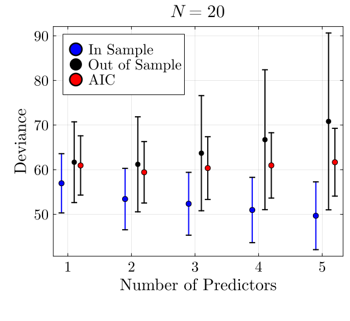

(a) Simulation of in vs. out of sample AIC calculations with increasing number of simulations

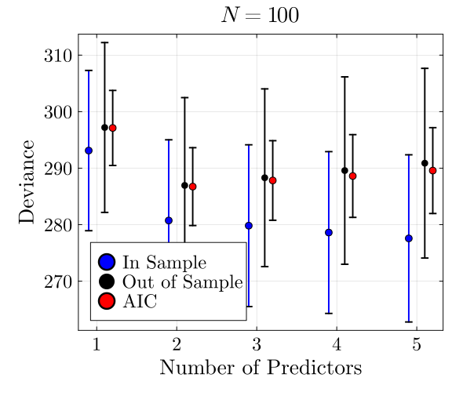

(b)

Figure 2

```julia
scatter!(p1, collect(1:5) .+ 0.2, d_20[:, 1] .+ 2 * (2:6), yerr=d_20[:, 2], lw=2, markersize=5, color=:red, linecolor=:black, label="AIC")

scatter!(p2, collect(1:5) .+ 0.2, d_100[:, 1] .+ 2 * (2:6), yerr=d_20[:, 2], lw=2, markersize=5, color=:red, linecolor=:black, label="AIC")

display(p1)
display(p2)
```

## AIC: Storm Surge Example

**Question**: Do climate oscillations (*e.g.* the Pacific Decadal Oscillation) result in variations in tidal extremes at the San Francisco tide gauge station?

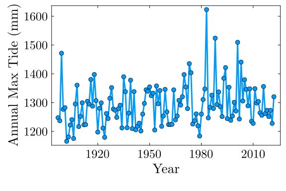

Figure 3: San Francisco tide gauge data

```julia
# load SF tide gauge data
# read in data and get annual maxima
function load_data(fname)
    date_format = DateFormat("yyyy-mm-dd HH:MM:SS")
    # This uses the DataFramesMeta.jl package, which makes it easy to string together commands to load and process data
    df = @chain fname begin
        CSV.read(DataFrame; header=false)
        rename("Column1" => "year", "Column2" => "month", "Column3" => "day", "Column4" => "hour", "Column5" => "gauge")
        # need to reformat the decimal date in the data file
        @transform :datetime = DateTime.(:year, :month, :day, :hour)
        # replace -99999 with missing
        @transform :gauge = ifelse.(abs.(:gauge) .>= 9999, missing, :gauge)
        select(:datetime, :gauge)
    end
    return df
end

dat = load_data("data/surge/h551.csv")

# detrend the data to remove the effects of sea-level rise and seasonal dynamics
ma_length = 366
ma_offset = Int(floor(ma_length/2))
moving_average(series,n) = [mean(@view series[i-n:i+n]) for i in n+1:length(series)-n]
dat_ma = DataFrame(datetime=dat.datetime[ma_offset+1:end-ma_offset], residual=dat.gauge[ma_offset+1:end-ma_offset] .- moving_average(dat.gauge, ma_offset))

# group data by year and compute the annual maxima
dat_ma = dropmissing(dat_ma) # drop missing data
dat_annmax = combine(dat_ma -> dat_ma[argmax(dat_ma.residual), :], groupby(DataFrames.transform(dat_ma, :datetime => x->year.(x)), :datetime_function))
delete!(dat_annmax, nrow(dat_annmax)) # delete 2023; haven't seen much of that year yet
rename!(dat_annmax, :datetime_function => :Year)
select!(dat_annmax, [:Year, :residual])

dat_annmax.residual = dat_annmax.residual  # convert to m

# make plots
psurge = plot(
    dat_annmax.Year,
    dat_annmax.residual;
    xlabel="Year",
    ylabel="Annual Max Tide (mm)",
    label=false,
    marker=:circle,
    markersize=5
)

plot!(psurge, size=(600, 400))
```

## AIC: Storm Surge Example

Models:

1. Stationary (“null”) model, $y_t \sim \text{GEV}(\mu, \sigma, \xi);$
2. Time nonstationary (“null-ish”) model, $y_t \sim \text{GEV}(\mu_0 + \mu_1 t, \sigma, \xi);$
3. PDO nonstationary model, $y_t \sim \text{GEV}(\mu_0 + \mu_1 \text{PDO}_t, \sigma, \xi)$

## AIC Example

```julia
stat_mle = [1258.71, 56.27, 0.017]
stat_ll = -707.67
nonstat_mle = [1231.58, 0.42, 52.07, 0.075]
nonstat_ll = -702.45
pdo_mle = [1255.87, -12.39, 54.73, 0.033]
pdo_ll = -705.24

# compute AIC values
stat_aic = stat_ll - 3
nonstat_aic = nonstat_ll - 4
pdo_aic = pdo_ll - 4

model_aic = DataFrame(Model=["Stationary", "Time", "PDO"], LogLik=trunc.(Int64, round.([stat_ll, nonstat_ll, pdo_ll]; digits=0)), AIC=trunc.(Int64, round.(-2 * [stat_aic, nonstat_aic, pdo_aic]; digits=0)))
```

3×3 DataFrame

| Row | Model String | LogLik Int64 | AIC Int64 |
| --- | --- | --- | --- |
| 1 | Stationary | -708 | 1421 |
| 2 | Time | -702 | 1413 |
| 3 | PDO | -705 | 1418 |

## AIC is Efficient, not Consistent

- **Efficiency**: Metric converges to K-L divergence/LOO-CV (Stone, 1977)
- **Consistency**: Metric will tend to choose the “true” model if it is included in the set.

This means **AIC selects for predictive performance, not “truth”.**

AIC can tend to overfit due to this prioritization of efficiency.

## AIC for Small Samples

AIC will tend to overfit (more parameters ⇒ more variance), penalty term isn’t strong enough to compensate.

$$\text{AIC}_c = \text{AIC} + \frac{2k^2 + 2k}{n - k - 1},$$

where

- $k = \text{dim}(\mathcal{M})$
- $n$ is the sample size.

## AIC Interpretation

Absolute AIC values have **no meaning**, only the differences $\Delta_i = \text{AIC}_i - \text{AIC}_\text{min}$.

Some basic rules of thumb (from Burnham & Anderson (2004)):

- $\Delta_i < 2$ means the model has “strong” support across $\mathcal{M}$;
- $4 < \Delta_i < 7$ suggests “less” support;
- $\Delta_i > 10$ suggests “weak” or “no” support.

## Model Averaging vs. Selection

Model averaging can sometimes be beneficial vs. model selection.

Model selection can introduce bias from the selection process (this is particularly acute for stepwise selection due to path-dependence).

## AIC and Model Evidence

$\exp(-\Delta_i/2)$ can be thought of as a measure of the likelihood of the model given the data $y$.

The ratio
$$\exp(-\Delta_i/2) / \exp(-\Delta_j/2)$$
can approximate the relative evidence for $M_i$ versus $M_j$.

## AIC and Model Averaging

This gives rise to the idea of *Akaike weights*:
$$w_i = \frac{\exp(-\Delta_i/2)}{\sum_{m=1}^M \exp(-\Delta_m/2)}.$$

Model projections can then be weighted based on $w_i$, which can be interpreted as the probability that $M_i$ is the best (in the sense of approximating the “true” predictive distribution) model in $\mathcal{M}$.

# Other Information Criteria

## Bayesian Information Criteria (BIC)

$$\text{BIC} = -2 \left(\log p(y | \hat{\theta}_\text{MLE})\right) + k\log n$$

Approximation of **log-marginal likelihood**
$$\log p(\mathcal{M}) = \log \int_\theta p(y | \theta, \mathcal{M}) p(\theta | \mathcal{M}) d\theta$$
under a whole host of assumptions related to large-sample approximation (so priors don’t matter).

Note that $\log p(\mathcal{M})$ is the *prior* predictive density, which is why BIC penalizes model complexity more than AIC.

## BIC For Model Comparison

When comparing two models $\mathcal{M}_1$, $\mathcal{M}_2$, get an approximation of the **log-Bayes Factor (BF)**:

$$\Delta \text{BIC} = \text{BIC}_1 - \text{BIC}_2 \approx \log \left(\frac{p(\mathcal{M}_1)}{p(\mathcal{M_2})}\right)$$

This means that $\Delta \text{BIC}$ gives an approximation of the posterior model probabilities across a model set assuming equal prior probabilities.

## BIC vs. AIC

- BIC tends to select more parsimonious models due to stronger penalty;
- AIC will tend to overfit, BIC to underfit.
- BIC is **consistent** but **not efficient**.

BIC vs. AIC is analogous to the tradeoff between causal vs. predictive analyses. **Generally not coherent to use both for the same problem**.

## Other Information Criteria

Follow the same pattern: compute $\text{elpd}$ based on some estimate and penalize for model degrees of freedom.

## Deviance Information Criteria (DIC)

The Deviance Information Criterion (DIC) is a more Bayesian generalization of AIC which uses the posterior mean
$$\hat{\theta}_\text{Bayes} = \mathbb{E}\left[\theta | y\right]$$
and a bias correction derived from the data.

## DIC Formula

$$\widehat{\text{elpd}}_\text{DIC} = \log p(y | \hat{\theta}_\text{Bayes}) - d_{\text{DIC}},$$
where
$$d_\text{DIC} = 2\left(\log p(y | \hat{\theta}_\text{Bayes}) - \mathbb{E}_\text{post}\left[\log p(y | \theta)\right]\right).$$

Then, as with AIC,
$$\text{DIC} = -2\widehat{\text{elpd}}_\text{DIC}.$$

## DIC: Effective Number of Parameters

**What is the meaning of $p_\text{DIC}$?**

- The difference between the average log-likelihood (across parameters) and the log-likelihood at a parameter average measures “degrees of freedom”.
- The DIC adjustment assumes independence of residuals for fixed $\theta$.

## AIC vs. DIC

AIC and DIC often give similar results, but don’t have to.

The key difference is the impact of priors on parameter estimation and model degrees of freedom.

## Watanabe-Akaike Information Criterion (WAIC)

$$\widehat{\text{elpd}}_\text{WAIC} = \sum_{i=1}^n \log \int p(y_i | \theta) p_\text{post}(\theta)\,d\theta - d_{\text{WAIC}},$$

where
$$d_\text{WAIC} = \sum_{i=1}^n \text{Var}_\text{post}\left(\log p(y_i | \theta)\right).$$

## WAIC Correction Factor

$p_\text{WAIC}$ is an estimate of the number of “unconstrained” parameters in the model.

- A parameter counts as 1 if its estimate is “independent” of the prior;
- A parameter counts as 0 if it is fully constrained by the prior.
- A parameter gives a partial value if both the data and prior are informative.

## WAIC vs. AIC and DIC

- WAIC can be viewed as an approximation to leave-one-out CV, and averages over the entire posterior, vs. AIC and DIC which use point estimates.
- But it doesn’t work well with highly structured data; no real alternative to more clever uses of Bayesian cross-validation.

# Key Takeaways and Upcoming Schedule

## Key Takeaways

- LOO-CV is ideal for navigating bias-variance tradeoff but can be computationally prohibitive.
- Information Criteria are an approximation to LOO-CV based on “correcting” for model complexity.
- Approximation to out of sample predictive error as a penalty for *potential to overfit*.
- Some ICs approximate K-L Divergence/LOO-CV, others approximate marginal likelihood. Different implications for predictive vs. causal modeling.

## Next Classes

**Wednesday**: Modeling Extreme Values

# References

## References

Burnham, K. P., & Anderson, D. R. (2004). Multimodel Inference: Understanding AIC and BIC in Model Selection. *Sociol. Methods Res.*, *33*, 261–304. https://doi.org/10.1177/0049124104268644

Stone, M. (1977). An asymptotic equivalence of choice of model by cross-validation and Akaike’s criterion. *J. R. Stat. Soc. Series B Stat. Methodol.*, *39*, 44–47. https://doi.org/10.1111/j.2517-6161.1977.tb01603.x